# Book | Programming Skills for Data Science | Exercises

Jesse Oliveira

09/10/2021

# Book Exercises

This is an R Markdown document with a personal solution to the exercises from the book [Programming Skills for Data Science](https://github.com/programming-for-data-science) from *Michael Freeman*.

## Chapter 4 - Using Markdown for Documentation

### Exercise 1

Using the text-edit of your choice (e.g., Atom), create a new file called README.md. Alternatively, you may clone this repository and edit this file. In your README.md document, put your favorite quote in a block quote, and provide a link to a website that provides additional information about the quote. Note that you can preview this Markdown in Atom to make sure it works correctly.

**Personal Solution**  
README.md

### Exercise 2

Using the text-edit of your choice (e.g., Atom), create a new file called README.md. Alternatively, you may clone this repository and edit this file. In your README.md document, make a three column table of the current courses you are taking, with separate columns for course number (in bold), course title (in italics), and instructor name. Note that you can preview this Markdown in Atom to make sure it works correctly.

**Personal Soluation**  
[Exercise 2 | README.md](https://github.com/o-jesse/Book---Programming-Skills-for-Data-Sience-Michael-Freman/blob/master/Exercise%202%20-%20README.md)

### Exercise 3

Using the text-edit of your choice (e.g., Atom), create a new file called README.md. Alternatively, you may clone this repository and edit this file. In your README.md document, provide some information about a terminal command you’ve learned thus far. In particular, you should include the following: - A heading with the name of the command; - An example of how it can be used (formatted as a code block); - A list of information about the command (i.e., things that it does, or how it can be used). *Note that you can preview this Markdown in Atom to make sure it works correctly.*

**Personal Solution**  
[Exercise 3 | README.md](https://github.com/o-jesse/Book---Programming-Skills-for-Data-Sience-Michael-Freman/blob/master/Exercise%203%20-%20README.md)

## Chapter 5

### Exercise 1: practice with basic R syntax

##### Create a variable `hometown` that stores the city in which you were born

```r
hometown <- "Campo Bom"
```

##### Assign your name to the variable `my_name`

```r
my_name <- "Jesse"
```

##### Assign your height (in inches) to a variable `my_height`

```r
my_height <- 70.8661
```

##### Create a variable `puppies` equal to the number of puppies you’d like to have

```r
puppies <- 3
```

##### Create a variable `puppy_price`, which is how much you think a puppy costs

```r
puppy_price <- 1000
```

##### Create a variable `total_cost` that has the total cost of all of your puppies

```r
total_cost <- puppies * puppy_price
total_cost
```

```
## [1] 3000
```

##### Create a boolean variable `too_expensive`, set to TRUE if the cost is greater

##### than $1,000

```r
too_expensive <- ifelse(total_cost > 1000,
                        TRUE,
                        FALSE
                        )
too_expensive
```

```
## [1] TRUE
```

##### Create a variable `max_puppies`, which is the number of puppies you can

##### afford for $1,000

```r
max_puppies <- 1000%/%puppy_price # %/% means divide and ignore remainder
max_puppies
```

```
## [1] 1
```

## Chapter 6

### Exercise 1: Exercise 1: calling built-in functions

#### Create a variable `my_name` that contains your name

```r
my_name <- "Jesse"
my_name
```

```
## [1] "Jesse"
```

#### Create a variable `name_length` that holds how many letters (including spaces)

#### are in your name (use the `nchar()` function)

```r
name_length <- nchar("Jesse Oliveira")
```

#### Print the number of letters in your name

```r
name_length
```

```
## [1] 14
```

#### Create a variable `now_doing` that is your name followed by “is programming!”

#### (use the `paste()` function)

```r
now_doing <- paste("Jesse", "is programming!")
now_doing
```

```
## [1] "Jesse is programming!"
```

#### Make the `now_doing` variable upper case

```r
toupper(now_doing)
```

```
## [1] "JESSE IS PROGRAMMING!"
```

### Bonus

#### Pick two of your favorite numbers (between 1 and 100) and assign them to

#### variables `fav_1` and `fav_2`

```r
fav_1 <- 7
fav_2 <- 14
```

#### Divide each number by the square root of 201 and save the new value in the

#### original variable

```r
fav_1 <- fav_1 / sqrt(201)
fav_1
```

```
## [1] 0.4937419
```

```r
fav_2 <- fav_2 / sqrt(201)
fav_2
```

```
## [1] 0.9874839
```

#### Create a variable `raw_sum` that is the sum of the two variables. Use the

#### `sum()` function for practice.

```r
raw_sum <- sum(fav_1+fav_2)
raw_sum
```

```
## [1] 1.481226
```

#### Create a variable `round_sum` that is the `raw_sum` rounded to 1 decimal place.

#### Use the `round()` function.

```r
round_sum <- round(raw_sum,1)
round_sum
```

```
## [1] 1.5
```

#### Create two new variables `round_1` and `round_2` that are your `fav_1` and

#### `fav_2` variables rounded to 1 decimal places

```r
round_1 <- round(fav_1,1)
round_1
```

```
## [1] 0.5
```

```r
round_2 <- round(fav_2,1)
round_2
```

```
## [1] 1
```

#### Create a variable `sum_round` that is the sum of the rounded values

```r
sum_round <- sum(round_1,round_2)
sum_round
```

```
## [1] 1.5
```

#### Which is bigger, `round_sum` or `sum_round`? (You can use the `max()` function!)

```r
round_sum
```

```
## [1] 1.5
```

```r
sum_round
```

```
## [1] 1.5
```

```r
max(round_sum,sum_round)
```

```
## [1] 1.5
```

### Exercise 2: using built-in string functions

#### Create a variable `lyric` that contains the text "I like to eat apples and

#### bananas"

```r
lyric <- "I like to eat apples and bananas"
lyric
```

```
## [1] "I like to eat apples and bananas"
```

#### Use the `substr()` function to extract the 1st through 13th letters from the

#### `lyric`, and store the result in a variable called `intro`

#### Use `?substr` to see more about this function

```r
intro <- substr(lyric,1,13)
intro
```

```
## [1] "I like to eat"
```

#### Use the `substr()` function to extract the 15th through the last letter of the

#### `lyric`, and store the result in a variable called `fruits`

#### Hint: use `nchar()` to determine how many total letters there are!

```r
fruits <- substr(lyric,15,nchar(lyric))
fruits
```

```
## [1] "apples and bananas"
```

#### Use the `gsub()` function to substitute all the “a”s in `fruits` with “ee”.

#### Store the result in a variable called `fruits_e`

#### Hint: see http://www.endmemo.com/program/R/sub.php for a simpmle example (or

#### use `?gsub`)

```r
fruits_e <- gsub("a","ee",fruits)
fruits_e
```

```
## [1] "eepples eend beeneenees"
```

#### Use the `gsub()` function to substitute all the “a”s in `fruits` with “o”.

#### Store the result in a variable called `fruits_o`

```r
fruits_o <- gsub("a","o",fruits)
fruits_o
```

```
## [1] "opples ond bononos"
```

#### Create a new variable `lyric_e` that is the `intro` combined with the new

#### `fruits_e` ending. Print out this variable

```r
lyric_e <- paste(intro,fruits_e)
print(lyric_e)
```

```
## [1] "I like to eat eepples eend beeneenees"
```

#### Without making a new variable, print out the `intro` combined with the new

#### `fruits_o` ending

```r
paste(intro,fruits_o)
```

```
## [1] "I like to eat opples ond bononos"
```

### Exercise 3: writing and executing functions

#### Define a function `add_three` that takes a single argument and

#### returns a value 3 greater than the input

```r
add_three <- function(value) {
  value + 3
}
```

#### Create a variable `ten` that is the result of passing 7 to your `add_three`

#### function

```r
ten <- add_three(7)
ten
```

```
## [1] 10
```

#### Define a function `imperial_to_metric` that takes in two arguments: a number

#### of feet and a number of inches

#### The function should return the equivalent length in meters

```r
imperial_to_metric <- function(feet,inches) {
  meters <- ( feet * 0.3048 ) + (inches * 0.0254)
  meters
}
```

#### Create a variable `height_in_meters` by passing your height in imperial to the

#### `imperial_to_metric` function

```r
height_in_meters <- imperial_to_metric(5,9.0551)
height_in_meters
```

```
## [1] 1.754
```

### Exercise 4: functions and conditionals

#### Define a function `is_twice_as_long` that takes in two character strings, and

#### returns whether or not (e.g., a boolean) the length of one argument is greater

#### than or equal to twice the length of the other.

#### Hint: compare the length difference to the length of the smaller string

Personal solution:

```r
is_twice_as_long <- function(string1,string2) {
  if(nchar(string1) >= nchar(string2)*2 ) {
    TRUE
  } else
  {FALSE}
}
```

Book solution: -> it is not necessary to use if (conditional) because R already evaluates TRUE or FALSE based on strings lengths.

```r
is_twice_as_long_book <- function(str1, str2) {
  diff <- abs(nchar(str1) - nchar(str2))
  min_length <- min(nchar(str1), nchar(str2))
  diff >= min_length # if difference is more than short
}
```

#### Call your `is_twice_as_long` function by passing it different length strings

#### to confirm that it works. Make sure to check when *either* argument is twice

#### as long, as well as when neither are!

Personal solution:

```r
call1 <- is_twice_as_long("lalala","lala")
call1
```

```
## [1] FALSE
```

```r
call2 <- is_twice_as_long("lalala","la")
call2
```

```
## [1] TRUE
```

```r
call3 <- is_twice_as_long("lala","la")
call3
```

```
## [1] TRUE
```

Book solution:

```r
is_twice_as_long_book("dog", "elephant")
```

```
## [1] TRUE
```

```r
is_twice_as_long_book("elephant", "dog")
```

```
## [1] TRUE
```

```r
is_twice_as_long_book("dog", "cat")
```

```
## [1] FALSE
```

#### Define a function `describe_difference` that takes in two strings. The

#### function should return one of the following sentences as appropriate

#### “Your first string is longer by N characters”

#### “Your second string is longer by N characters”

#### “Your strings are the same length!”

```r
describe_difference <- function(string1,string2) {
  if (nchar(string1) > nchar(string2) ) {
    difference <- paste("Your first string is longer by",nchar(string1)-nchar(string2),"characters" )
  } else if (nchar(string1) < nchar(string2)) {
    difference <- paste("Your second string is longer by", nchar(string1)-nchar(string2) ,"characters")
  } else {
    difference <- "your strings are the same length!"
  }
  difference
}
```

#### Call your `describe_difference` function by passing it different length strings

#### to confirm that it works. Make sure to check all 3 conditions

```r
describe_difference("Australia","Brazil")
```

```
## [1] "Your first string is longer by 3 characters"
```

```r
describe_difference("Brasil","Italy")
```

```
## [1] "Your first string is longer by 1 characters"
```

```r
describe_difference("Sweden","Brazil")
```

```
## [1] "your strings are the same length!"
```

### Chapter 7

#### Exercise 1: creating and operating on vectors

#### Create a vector `names` that contains your name and the names of 2 people

#### next to you. Print the vector.

```r
names <- c("Jesse","John","Doe")
print(names)
```

```
## [1] "Jesse" "John"  "Doe"
```

#### Use the colon operator : to create a vector `n` of numbers from 10:49

```r
n <- 10:49
n
```

```
##  [1] 10 11 12 13 14 15 16 17 18 19 20 21 22 23 24 25 26 27 28 29 30 31 32 33 34
## [26] 35 36 37 38 39 40 41 42 43 44 45 46 47 48 49
```

#### Use the `length()` function to get the number of elements in `n`

```r
length(n)
```

```
## [1] 40
```

#### Add 1 to each element in `n` and print the result

```r
print(n +1)
```

```
##  [1] 11 12 13 14 15 16 17 18 19 20 21 22 23 24 25 26 27 28 29 30 31 32 33 34 35
## [26] 36 37 38 39 40 41 42 43 44 45 46 47 48 49 50
```

#### Create a vector `m` that contains the numbers 10 to 1 (in that order).

#### Hint: use the `seq()` function

```r
m <- seq(from=10,to=1)
m
```

```
##  [1] 10  9  8  7  6  5  4  3  2  1
```

#### Subtract `m` FROM `n`. Note the recycling!

```r
n - m
```

```
##  [1]  0  2  4  6  8 10 12 14 16 18 10 12 14 16 18 20 22 24 26 28 20 22 24 26 28
## [26] 30 32 34 36 38 30 32 34 36 38 40 42 44 46 48
```

#### Use the `seq()` function to produce a range of numbers from -5 to 10 in `0.1`

#### increments. Store it in a variable `x_range`

```r
x_range <- seq(from=-5,to=10,by=0.1)
x_range
```

```
##   [1] -5.0 -4.9 -4.8 -4.7 -4.6 -4.5 -4.4 -4.3 -4.2 -4.1 -4.0 -3.9 -3.8 -3.7 -3.6
##  [16] -3.5 -3.4 -3.3 -3.2 -3.1 -3.0 -2.9 -2.8 -2.7 -2.6 -2.5 -2.4 -2.3 -2.2 -2.1
##  [31] -2.0 -1.9 -1.8 -1.7 -1.6 -1.5 -1.4 -1.3 -1.2 -1.1 -1.0 -0.9 -0.8 -0.7 -0.6
##  [46] -0.5 -0.4 -0.3 -0.2 -0.1  0.0  0.1  0.2  0.3  0.4  0.5  0.6  0.7  0.8  0.9
##  [61]  1.0  1.1  1.2  1.3  1.4  1.5  1.6  1.7  1.8  1.9  2.0  2.1  2.2  2.3  2.4
##  [76]  2.5  2.6  2.7  2.8  2.9  3.0  3.1  3.2  3.3  3.4  3.5  3.6  3.7  3.8  3.9
##  [91]  4.0  4.1  4.2  4.3  4.4  4.5  4.6  4.7  4.8  4.9  5.0  5.1  5.2  5.3  5.4
## [106]  5.5  5.6  5.7  5.8  5.9  6.0  6.1  6.2  6.3  6.4  6.5  6.6  6.7  6.8  6.9
## [121]  7.0  7.1  7.2  7.3  7.4  7.5  7.6  7.7  7.8  7.9  8.0  8.1  8.2  8.3  8.4
## [136]  8.5  8.6  8.7  8.8  8.9  9.0  9.1  9.2  9.3  9.4  9.5  9.6  9.7  9.8  9.9
## [151] 10.0
```

#### Create a vector `sin_wave` by calling the `sin()` function on each element

#### in `x_range`.

```r
sin_wave <- sin(x_range)
sin_wave
```

```
##   [1]  0.95892427  0.98245261  0.99616461  0.99992326  0.99369100  0.97753012
##   [7]  0.95160207  0.91616594  0.87157577  0.81827711  0.75680250  0.68776616
##  [13]  0.61185789  0.52983614  0.44252044  0.35078323  0.25554110  0.15774569
##  [19]  0.05837414 -0.04158066 -0.14112001 -0.23924933 -0.33498815 -0.42737988
##  [25] -0.51550137 -0.59847214 -0.67546318 -0.74570521 -0.80849640 -0.86320937
##  [31] -0.90929743 -0.94630009 -0.97384763 -0.99166481 -0.99957360 -0.99749499
##  [37] -0.98544973 -0.96355819 -0.93203909 -0.89120736 -0.84147098 -0.78332691
##  [43] -0.71735609 -0.64421769 -0.56464247 -0.47942554 -0.38941834 -0.29552021
##  [49] -0.19866933 -0.09983342  0.00000000  0.09983342  0.19866933  0.29552021
##  [55]  0.38941834  0.47942554  0.56464247  0.64421769  0.71735609  0.78332691
##  [61]  0.84147098  0.89120736  0.93203909  0.96355819  0.98544973  0.99749499
##  [67]  0.99957360  0.99166481  0.97384763  0.94630009  0.90929743  0.86320937
##  [73]  0.80849640  0.74570521  0.67546318  0.59847214  0.51550137  0.42737988
##  [79]  0.33498815  0.23924933  0.14112001  0.04158066 -0.05837414 -0.15774569
##  [85] -0.25554110 -0.35078323 -0.44252044 -0.52983614 -0.61185789 -0.68776616
##  [91] -0.75680250 -0.81827711 -0.87157577 -0.91616594 -0.95160207 -0.97753012
##  [97] -0.99369100 -0.99992326 -0.99616461 -0.98245261 -0.95892427 -0.92581468
## [103] -0.88345466 -0.83226744 -0.77276449 -0.70554033 -0.63126664 -0.55068554
## [109] -0.46460218 -0.37387666 -0.27941550 -0.18216250 -0.08308940  0.01681390
## [115]  0.11654920  0.21511999  0.31154136  0.40484992  0.49411335  0.57843976
## [121]  0.65698660  0.72896904  0.79366786  0.85043662  0.89870810  0.93799998
## [127]  0.96791967  0.98816823  0.99854335  0.99894134  0.98935825  0.96988981
## [133]  0.94073056  0.90217183  0.85459891  0.79848711  0.73439710  0.66296923
## [139]  0.58491719  0.50102086  0.41211849  0.31909836  0.22288991  0.12445442
## [145]  0.02477543 -0.07515112 -0.17432678 -0.27176063 -0.36647913 -0.45753589
## [151] -0.54402111
```

#### Create a vector `cos_wave` by calling the `cos()` function on each element

#### in `x_range`.

```r
cos_wave <- cos(x_range)
cos_wave
```

```
##   [1]  0.28366219  0.18651237  0.08749898 -0.01238866 -0.11215253 -0.21079580
##   [7] -0.30733287 -0.40079917 -0.49026082 -0.57482395 -0.65364362 -0.72593230
##  [13] -0.79096771 -0.84810003 -0.89675842 -0.93645669 -0.96679819 -0.98747977
##  [19] -0.99829478 -0.99913515 -0.98999250 -0.97095817 -0.94222234 -0.90407214
##  [25] -0.85688875 -0.80114362 -0.73739372 -0.66627602 -0.58850112 -0.50484610
##  [31] -0.41614684 -0.32328957 -0.22720209 -0.12884449 -0.02919952  0.07073720
##  [37]  0.16996714  0.26749883  0.36235775  0.45359612  0.54030231  0.62160997
##  [43]  0.69670671  0.76484219  0.82533561  0.87758256  0.92106099  0.95533649
##  [49]  0.98006658  0.99500417  1.00000000  0.99500417  0.98006658  0.95533649
##  [55]  0.92106099  0.87758256  0.82533561  0.76484219  0.69670671  0.62160997
##  [61]  0.54030231  0.45359612  0.36235775  0.26749883  0.16996714  0.07073720
##  [67] -0.02919952 -0.12884449 -0.22720209 -0.32328957 -0.41614684 -0.50484610
##  [73] -0.58850112 -0.66627602 -0.73739372 -0.80114362 -0.85688875 -0.90407214
##  [79] -0.94222234 -0.97095817 -0.98999250 -0.99913515 -0.99829478 -0.98747977
##  [85] -0.96679819 -0.93645669 -0.89675842 -0.84810003 -0.79096771 -0.72593230
##  [91] -0.65364362 -0.57482395 -0.49026082 -0.40079917 -0.30733287 -0.21079580
##  [97] -0.11215253 -0.01238866  0.08749898  0.18651237  0.28366219  0.37797774
## [103]  0.46851667  0.55437434  0.63469288  0.70866977  0.77556588  0.83471278
## [109]  0.88551952  0.92747843  0.96017029  0.98326844  0.99654210  0.99985864
## [115]  0.99318492  0.97658763  0.95023259  0.91438315  0.86939749  0.81572510
## [121]  0.75390225  0.68454667  0.60835131  0.52607752  0.43854733  0.34663532
## [127]  0.25125984  0.15337386  0.05395542 -0.04600213 -0.14550003 -0.24354415
## [133] -0.33915486 -0.43137684 -0.51928865 -0.60201190 -0.67872005 -0.74864665
## [139] -0.81109301 -0.86543521 -0.91113026 -0.94772160 -0.97484362 -0.99222533
## [145] -0.99969304 -0.99717216 -0.98468786 -0.96236488 -0.93042627 -0.88919115
## [151] -0.83907153
```

#### Create a vector `wave` by multiplying `sin_wave` and `cos_wave` together, then

#### adding `sin_wave` to the product

```r
wave <- (sin_wave * cos_wave) + sin_wave
wave
```

```
##   [1]  1.230935e+00  1.165692e+00  1.083328e+00  9.875355e-01  8.822460e-01
##   [6]  7.714709e-01  6.591435e-01  5.489674e-01  4.442763e-01  3.479118e-01
##  [11]  2.621234e-01  1.884945e-01  1.278981e-01  8.048209e-02  4.568651e-02
##  [16]  2.228993e-02  8.484426e-03  1.975012e-03  9.954100e-05 -3.596102e-05
##  [21] -1.412259e-03 -6.948240e-03 -1.935483e-02 -4.099764e-02 -7.377404e-02
##  [26] -1.190100e-01 -1.773809e-01 -2.488597e-01 -3.326954e-01 -4.274215e-01
##  [31] -5.308962e-01 -6.403711e-01 -7.525874e-01 -8.638943e-01 -9.703865e-01
##  [36] -1.068055e+00 -1.152944e+00 -1.221309e+00 -1.269771e+00 -1.295456e+00
##  [41] -1.296120e+00 -1.270251e+00 -1.217143e+00 -1.136943e+00 -1.030662e+00
##  [46] -9.001610e-01 -7.480964e-01 -5.778414e-01 -3.933785e-01 -1.991681e-01
##  [51]  0.000000e+00  1.991681e-01  3.933785e-01  5.778414e-01  7.480964e-01
##  [56]  9.001610e-01  1.030662e+00  1.136943e+00  1.217143e+00  1.270251e+00
##  [61]  1.296120e+00  1.295456e+00  1.269771e+00  1.221309e+00  1.152944e+00
##  [66]  1.068055e+00  9.703865e-01  8.638943e-01  7.525874e-01  6.403711e-01
##  [71]  5.308962e-01  4.274215e-01  3.326954e-01  2.488597e-01  1.773809e-01
```

[output cut: 16 more lines]

#### Use the `plot()` function to plot your `wave`!

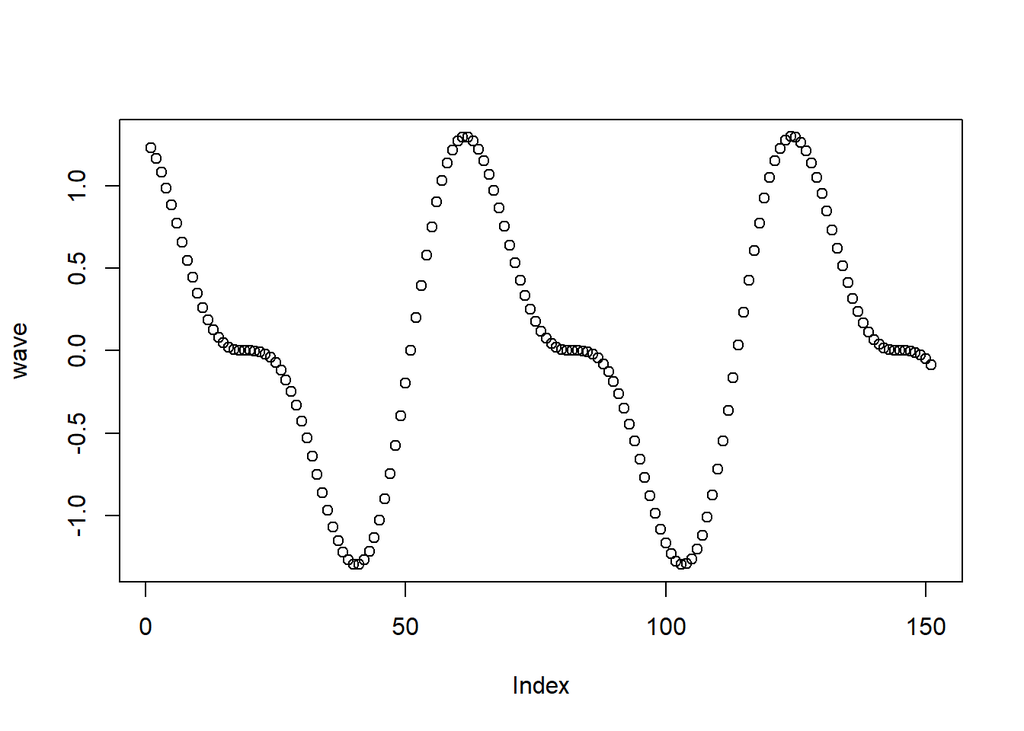

```r
plot(wave)
```

### Exercise 2: indexing and filtering vectors

#### Create a vector `first_ten` that has the values 10 through 20 in it (using

#### the : operator)

```r
first_ten <- 10:20
first_ten
```

```
##  [1] 10 11 12 13 14 15 16 17 18 19 20
```

#### Create a vector `next_ten` that has the values 21 through 30 in it (using the

#### seq() function)

```r
next_ten <- seq(from=21,to=30)
next_ten
```

```
##  [1] 21 22 23 24 25 26 27 28 29 30
```

#### Create a vector `all_numbers` by combining the previous two vectors

```r
all_numbers <- c(first_ten,next_ten)
all_numbers
```

```
##  [1] 10 11 12 13 14 15 16 17 18 19 20 21 22 23 24 25 26 27 28 29 30
```

#### Create a variable `eleventh` that contains the 11th element in `all_numbers`

```r
eleventh <- all_numbers[11]
eleventh
```

```
## [1] 20
```

#### Create a vector `some_numbers` that contains the 2nd through the 5th elements

#### of `all_numbers`

```r
some_numbers <- all_numbers[2:5]
some_numbers
```

```
## [1] 11 12 13 14
```

#### Create a vector `even` that holds the even numbers from 1 to 100

```r
even <- seq(from=2,to=100, by=2)
even
```

```
##  [1]   2   4   6   8  10  12  14  16  18  20  22  24  26  28  30  32  34  36  38
## [20]  40  42  44  46  48  50  52  54  56  58  60  62  64  66  68  70  72  74  76
## [39]  78  80  82  84  86  88  90  92  94  96  98 100
```

#### Using the `all()` function and `%%` (modulo) operator, confirm that all of the

#### numbers in your `even` vector are even

```r
all(even %% 2 == 0)
```

```
## [1] TRUE
```

#### Create a vector `phone_numbers` that contains the numbers 8, 6, 7, 5, 3, 0, 9

```r
phone_numbers <- c(8,6,7,5,3,0,9)
phone_numbers
```

```
## [1] 8 6 7 5 3 0 9
```

#### Create a vector `prefix` that has the first three elements of `phone_numbers`

```r
prefix <- phone_numbers[1:3]
prefix
```

```
## [1] 8 6 7
```

#### Create a vector `small` that has the values of `phone_numbers` that are

#### less than or equal to 5

```r
small <- phone_numbers[phone_numbers <= 5]
small
```

```
## [1] 5 3 0
```

#### Create a vector `large` that has the values of `phone_numbers` that are

#### strictly greater than 5

```r
large <- phone_numbers[phone_numbers > 5]
large
```

```
## [1] 8 6 7 9
```

#### Replace the values in `phone_numbers` that are larger than 5 with the number 5

```r
phone_numbers[phone_numbers > 5] <- 5
phone_numbers
```

```
## [1] 5 5 5 5 3 0 5
```

#### Replace every odd-numbered value in `phone_numbers` with the number 0

```r
phone_numbers[phone_numbers %% 2 != 0] <- 0
phone_numbers
```

```
## [1] 0 0 0 0 0 0 0
```

### Exercise 3: vector practice

#### Create a vector `words` of 6 (or more) words.

#### You can Google for a “random word generator” if you wish!

```r
words <- c("table", "desk", "microscope", "laptop","keyboard","mouse")
words
```

```
## [1] "table"      "desk"       "microscope" "laptop"     "keyboard"
## [6] "mouse"
```

#### Create a vector `words_of_the_day` that is your `words` vector with the string

#### “is the word of the day!” pasted on to the end.

#### BONUS: Surround the word in quotes (e.g., `'data' is the word of the day!`)

#### Note that the results are more obviously correct with single quotes.

```r
words_of_the_day <- paste("'",words,"' is the word of the day!", sep = "")
words_of_the_day
```

```
## [1] "'table' is the word of the day!"
## [2] "'desk' is the word of the day!"
## [3] "'microscope' is the word of the day!"
## [4] "'laptop' is the word of the day!"
## [5] "'keyboard' is the word of the day!"
## [6] "'mouse' is the word of the day!"
```

#### Hint: use a comparison operator to see if the word comes before “f” alphabetically!

#### Tip: make sure all the words are lower-case, and only consider the first letter

#### of the word!

```r
a_f_words <- words[substring(words,1,2) <= "f"]
a_f_words
```

```
## [1] "desk"
```

#### Create a vector `g_m_words` which are the elements in `words` that start with

#### “g” through “m”

```r
g_m_words <- words[substring(words,1,1) >= "g" & substring(words,1,1) <= "m"]
g_m_words
```

```
## [1] "microscope" "laptop"     "keyboard"   "mouse"
```

#### Define a function `word_bin` that takes in three arguments: a vector of words,

#### and two letters. The function should return a vector of words that go between

#### those letters alphabetically.

```r
word_bin <- function(words,start,end) {
  words[substring(words,1,1) >= start & substring(words,1,1) <= end]
}
```

#### Use your `word_bin` function to determine which of your words start with “e”

#### through “q”

```r
word_bin(words,"e","q")
```

```
## [1] "microscope" "laptop"     "keyboard"   "mouse"
```

### Chapter 8

#### Exercise 1: creating and accessing lists

#### Create a vector `my_breakfast` of everything you ate for breakfast

```r
my_breakfast <- c("milk","cereal")
my_breakfast
```

```
## [1] "milk"   "cereal"
```

#### Create a vector `my_lunch` of everything you ate (or will eat) for lunch

```r
my_lunch <- c("rice","beans","chicken","potato","veggies")
my_lunch
```

```
## [1] "rice"    "beans"   "chicken" "potato"  "veggies"
```

#### Create a list `meals` that has contains your breakfast and lunch

```r
meals <- list(breakfast=my_breakfast,lunch=my_lunch)
meals
```

```
## $breakfast
## [1] "milk"   "cereal"
##
## $lunch
## [1] "rice"    "beans"   "chicken" "potato"  "veggies"
```

#### Add a “dinner” element to your `meals` list that has what you plan to eat

#### for dinner

```r
meals$dinner <- c("sushi","coke")
```

#### Use dollar notation to extract your `dinner` element from your list

#### and save it in a vector called ‘dinner’

```r
dinner <- meals$dinner
dinner
```

```
## [1] "sushi" "coke"
```

#### Use double-bracket notation to extract your `lunch` element from your list

#### and save it in your list as the element at index 5 (no reason beyond practice)

```r
meals[[5]] <- meals[["lunch"]]
meals[[5]]
```

```
## [1] "rice"    "beans"   "chicken" "potato"  "veggies"
```

#### Use single-bracket notation to extract your breakfast and lunch from your list

#### and save them to a list called `early_meals`

```r
early_meals <- meals[1:2]
early_meals
```

```
## $breakfast
## [1] "milk"   "cereal"
##
## $lunch
## [1] "rice"    "beans"   "chicken" "potato"  "veggies"
```

### Challenge

#### Create a list that has the number of items you ate for each meal

#### Hint: use the `lapply()` function to apply the `length()` function to each item

```r
lapply(meals,length)
```

```
## $breakfast
## [1] 2
##
## $lunch
## [1] 5
##
## $dinner
## [1] 2
##
## [[4]]
## [1] 0
##
## [[5]]
## [1] 5
```

#### Write a function `add_pizza` that adds pizza to a given meal vector, and

#### returns the pizza-fied vector

```r
add_pizza <- function(meal) {
  meals <- c(meal,"pizza")
  meals
}
```

#### Create a vector `better_meals` that is all your meals, but with pizza!

```r
better_meals <- c(add_pizza(meals))
better_meals
```

```
## $breakfast
## [1] "milk"   "cereal"
##
## $lunch
## [1] "rice"    "beans"   "chicken" "potato"  "veggies"
##
## $dinner
## [1] "sushi" "coke"
##
## [[4]]
## NULL
##
## [[5]]
## [1] "rice"    "beans"   "chicken" "potato"  "veggies"
##
## [[6]]
## [1] "pizza"
```

### Exercise 2: using `*apply()` functions

#### Create a *list* of 10 random numbers. Use the `runif()` function to make a

#### vector of random numbers, then use `as.list()` to convert that to a list

```r
ten_randon_number <- as.list(runif(10))
ten_randon_number
```

```
## [[1]]
## [1] 0.899195
##
## [[2]]
## [1] 0.8425266
##
## [[3]]
## [1] 0.8001838
##
## [[4]]
## [1] 0.2436719
##
## [[5]]
## [1] 0.08400271
##
## [[6]]
## [1] 0.658298
##
## [[7]]
## [1] 0.6733759
##
## [[8]]
## [1] 0.8770395
##
## [[9]]
## [1] 0.511834
##
## [[10]]
## [1] 0.4262333
```

#### Use `lapply()` to apply the `round()` function to each number, rounding it to

# the nearest 0.1 (one decimal place)

```r
rounded_ten_random_numbers <- lapply(ten_randon_number,round,1)
rounded_ten_random_numbers
```

```
## [[1]]
## [1] 0.9
##
## [[2]]
## [1] 0.8
##
## [[3]]
## [1] 0.8
##
## [[4]]
## [1] 0.2
##
## [[5]]
## [1] 0.1
##
## [[6]]
## [1] 0.7
##
## [[7]]
## [1] 0.7
##
## [[8]]
## [1] 0.9
##
## [[9]]
## [1] 0.5
##
## [[10]]
## [1] 0.4
```

#### Create a variable ‘sentence’ that contains a sentence of text (something

#### longish). Make the sentence lowercase; you can use a function to help.

```r
sentence <- tolower("The Lawes will work to transform you into a calmer and more strategic observer of people, helping to free you from all the motional drama that needlessly drains you.")
sentence
```

```
## [1] "the lawes will work to transform you into a calmer and more strategic observer of people, helping to free you from all the motional drama that needlessly drains you."
```

#### Use the `strsplit()` function to split the sentence into a vector of letters.

#### Hint: split on `""` to split every character

#### Note: this will return a *list* with 1 element (which is the vector of letters)

```r
split_sentence <- strsplit(sentence,split="")
split_sentence
```

```
## [[1]]
##   [1] "t" "h" "e" " " "l" "a" "w" "e" "s" " " "w" "i" "l" "l" " " "w" "o" "r"
##  [19] "k" " " "t" "o" " " "t" "r" "a" "n" "s" "f" "o" "r" "m" " " "y" "o" "u"
##  [37] " " "i" "n" "t" "o" " " "a" " " "c" "a" "l" "m" "e" "r" " " "a" "n" "d"
##  [55] " " "m" "o" "r" "e" " " "s" "t" "r" "a" "t" "e" "g" "i" "c" " " "o" "b"
##  [73] "s" "e" "r" "v" "e" "r" " " "o" "f" " " "p" "e" "o" "p" "l" "e" "," " "
##  [91] "h" "e" "l" "p" "i" "n" "g" " " "t" "o" " " "f" "r" "e" "e" " " "y" "o"
## [109] "u" " " "f" "r" "o" "m" " " "a" "l" "l" " " "t" "h" "e" " " "m" "o" "t"
## [127] "i" "o" "n" "a" "l" " " "d" "r" "a" "m" "a" " " "t" "h" "a" "t" " " "n"
## [145] "e" "e" "d" "l" "e" "s" "s" "l" "y" " " "d" "r" "a" "i" "n" "s" " " "y"
## [163] "o" "u" "."
```

#### Extract the vector of letters from the resulting list

```r
letters <- split_sentence[[1]]
letters
```

```
##   [1] "t" "h" "e" " " "l" "a" "w" "e" "s" " " "w" "i" "l" "l" " " "w" "o" "r"
##  [19] "k" " " "t" "o" " " "t" "r" "a" "n" "s" "f" "o" "r" "m" " " "y" "o" "u"
##  [37] " " "i" "n" "t" "o" " " "a" " " "c" "a" "l" "m" "e" "r" " " "a" "n" "d"
##  [55] " " "m" "o" "r" "e" " " "s" "t" "r" "a" "t" "e" "g" "i" "c" " " "o" "b"
##  [73] "s" "e" "r" "v" "e" "r" " " "o" "f" " " "p" "e" "o" "p" "l" "e" "," " "
##  [91] "h" "e" "l" "p" "i" "n" "g" " " "t" "o" " " "f" "r" "e" "e" " " "y" "o"
## [109] "u" " " "f" "r" "o" "m" " " "a" "l" "l" " " "t" "h" "e" " " "m" "o" "t"
## [127] "i" "o" "n" "a" "l" " " "d" "r" "a" "m" "a" " " "t" "h" "a" "t" " " "n"
## [145] "e" "e" "d" "l" "e" "s" "s" "l" "y" " " "d" "r" "a" "i" "n" "s" " " "y"
## [163] "o" "u" "."
```

#### Use the `unique()` function to get a vector of unique letters

```r
unique_letters <- unique(letters)
unique_letters
```

```
##  [1] "t" "h" "e" " " "l" "a" "w" "s" "i" "o" "r" "k" "n" "f" "m" "y" "u" "c" "d"
## [20] "g" "b" "v" "p" "," "."
```

#### Define a function `count_occurrences` that takes in two parameters: a letter

#### and a vector of letters. The function should return how many times that letter

#### occurs in the provided vector.

#### Hint: use a filter operation!

```r
count_occurrences <- function(letter,vector) {
  length(vector[vector==letter])
}
```

#### Call your `count_occurrences()` function to see how many times the letter ‘e’

#### is in your sentence.

```r
count_occurrences("e",unique_letters)
```

```
## [1] 1
```

#### Use `sapply()` to apply your `count_occurrences()` function to each unique

#### letter in the vector to determine their frequencies.

#### Convert the result into a list (using `as.list()`).

```r
frequencies <- as.list(
  sapply(
    unique_letters,count_occurrences,letters
  )
)
```

#### Print the resulting list of frequencies

```r
frequencies
```

```
## $t
## [1] 11
##
## $h
## [1] 4
##
## $e
## [1] 16
##
## $` `
## [1] 28
##
## $l
## [1] 11
##
## $a
## [1] 12
##
## $w
## [1] 3
##
## $s
## [1] 7
##
## $i
## [1] 6
##
## $o
## [1] 15
##
## $r
## [1] 12
##
## $k
## [1] 1
##
## $n
## [1] 7
##
## $f
```

[output cut: 19 more lines]

```
##
## $b
## [1] 1
##
## $v
## [1] 1
##
## $p
## [1] 3
##
## $`,`
## [1] 1
##
## $.
## [1] 1
```

## Chapter 11

### Exercise 1 and 2: working with data frames (review)

#### Install devtools package: allows installations from GitHub

```r
# install.packages("devtools") - this has been commented out so it doesn't install every time a run the codes. "devtools" package has been installed.
```

#### Install “fueleconomy” dataset from GitHub

```r
# devtools::install_github("hadley/fueleconomy") - this has been commented out so it doesn't install every time a run the codes. "fueleconomy" package has been installed.
```

#### Use the `libary()` function to load the “fueleconomy” package

```r
library(fueleconomy)
```

#### You should now have access to the `vehicles` data frame

#### You can use `View()` to inspect it

```r
# View(vehicles) - this has been commented out as this dataset is humongous.
```

#### Select the different manufacturers (makes) of the cars in this data set.

#### Save this vector in a variable

##### rbase

```r
makes <- vehicles$make
```

##### dplyr

```r
makes <- select(vehicles,make)
```

#### Use the `unique()` function to determine how many different car manufacturers

#### are represented by the data set

#### for dplyr, use `distinct()`

##### non-dplyr

```r
length(unique(makes))
```

```
## [1] 1
```

##### dplyr

```r
makes_dplyr <- vehicles %>%
  distinct(make) %>%
  nrow()
```

#### Filter the data set for vehicles manufactured in 1997

```r
vehicles_1997 <- vehicles[vehicles$year==1997,]
vehicles_1997
```

```
## # A tibble: 762 x 12
##       id make  model        year class trans drive   cyl displ fuel    hwy   cty
##    <dbl> <chr> <chr>       <dbl> <chr> <chr> <chr> <dbl> <dbl> <chr> <dbl> <dbl>
##  1 13309 Acura 2.2CL/3.0CL  1997 Subc~ Auto~ Fron~     4   2.2 Regu~    26    20
##  2 13310 Acura 2.2CL/3.0CL  1997 Subc~ Manu~ Fron~     4   2.2 Regu~    28    22
##  3 13311 Acura 2.2CL/3.0CL  1997 Subc~ Auto~ Fron~     6   3   Regu~    26    18
##  4 13421 Acura 2.5TL/3.2TL  1997 Comp~ Auto~ Fron~     5   2.5 Prem~    23    18
##  5 13422 Acura 2.5TL/3.2TL  1997 Comp~ Auto~ Fron~     6   3.2 Prem~    22    17
##  6 13537 Acura 3.5RL        1997 Mids~ Auto~ Fron~     6   3.5 Prem~    23    17
##  7 13306 Acura Integra      1997 Subc~ Manu~ Fron~     4   1.8 Prem~    29    22
##  8 13307 Acura Integra      1997 Subc~ Auto~ Fron~     4   1.8 Regu~    29    21
##  9 13308 Acura Integra      1997 Subc~ Manu~ Fron~     4   1.8 Regu~    29    22
## 10 13919 Acura SLX          1997 Spec~ Auto~ 4-Wh~     6   3.2 Regu~    17    13
## # ... with 752 more rows
```

#### Arrange the 1997 cars by highway (`hwy`) gas milage

#### Hint: use the `order()` function to get a vector of indices in order by value

#### See also: https://www.r-bloggers.com/r-sorting-a-data-frame-by-the-contents-of-a-column/

```r
vehicles_1997 <- vehicles_1997[order(vehicles$hwy),]
```

#### Mutate the 1997 cars data frame to add a column `average` that has the average

#### gas milage (between city and highway mpg) for each car

##### Personal Solution

```r
cars_1997 <- vehicles_1997 %>%
  group_by(make) %>%
  mutate(
    avg = (hwy + cty) / 2
  )
```

##### Book Solution

```r
vehicles_1997$average <- (vehicles_1997$hwy + vehicles_1997$cty) / 2
```

#### Filter the whole vehicles data set for 2-Wheel Drive vehicles that get more

#### than 20 miles/gallon in the city.

#### Save this new data frame in a variable.

##### Personal solution

```r
two_wheel_20mpg <- vehicles %>%
  filter(
    drive == "2-Wheel Drive" & cty > 20
  )
```

##### Book solution

```r
two_wheel_20_mpg <- vehicles[vehicles$drive == "2-Wheel Drive" & vehicles$cty > 20,]
```

#### Hint: filter for the worst vehicle, then select its ID.

##### Personal solution (filtering the entire row)

```r
worst_hwy <- two_wheel_20mpg %>%
  filter(hwy == min(hwy))
```

##### Book solution (filtering the entire row)

```r
worst_hwy2 <- two_wheel_20mpg[two_wheel_20mpg$hwy == min(two_wheel_20mpg$hwy),]
```

##### Book solution (ID only)

```r
worst_hwy_book <- two_wheel_20mpg$id[two_wheel_20mpg$hwy == min(two_wheel_20mpg$hwy)]
```

#### Write a function that takes a `year_choice` and a `make_choice` as parameters,

#### and returns the vehicle model that gets the most hwy miles/gallon of vehicles

#### of that make in that year.

#### You’ll need to filter more (and do some selecting)!

```r
year_make_choice <- function(year_choice,make_choice) {
  filtered <- vehicles[vehicles$year == year_choice & vehicles$make == make_choice,]
  filtered[filtered$hwy == max(filtered$hwy),"model"]

}
```

#### What was the most efficient Honda model of 1995?

```r
year_make_choice(1995,"Honda")
```

```
## # A tibble: 1 x 1
##   model
##   <chr>
## 1 Civic HB VX
```

### Exercise 2: working with `dplyr`